# Fishing and Hunting Implements

Osmond, M.

An earlier version of this chapter is included in Lynch and Pat, eds, (1996). I am grateful to Andrew Pawley and Malcolm Ross who have contributed substantially to the preparation of this chapter, to Atholl Anderson for his comments and to Jean Kennedy for drawing my attention to P.H. (Holly) McEldowney’s (1995) thesis (1995), which contains a wealth of information on fishing techniques in the Admiralties.

## 1. Introduction

This chapter takes a close look at terms for fishing and hunting implements and processes attributable to Proto Oceanic (POc), with a view to reconstructing a small portion of the culture of POc speakers.[^1] There is ample linguistic evidence that these people were fishermen and seafarers. The Oceanic Lexicon Project has collected cognate sets supporting POc reconstructions for over eighty fish names and an additional forty terms for shellfish (see vol. 3). This paper adds a further twenty terms for various fishing techniques used, both for deep-sea fishing requiring line and hook capture and for coastal, reef or river fishing where netting, spearing, poisoning or fish-trapping could suffice. We also know that a number of animals, birds and reptiles were hunted for food, and terms for many of these have been reconstructed. Here we attempt to establish terms for the hunting implements and techniques used.

## 2. Nets

Most Oceanic languages have a wide range of terms for different kinds of nets. These include terms for hand nets, casting nets, seine nets, long-handled nets for catching flying fish, and so on. Many languages have terms for nets for catching birds and occasionally larger animals, such as pigs and wallabies. Presumably there were POc terms for a wider range of nets than the four we have reconstructed.

| **PMP** |  | *puket | [N] ‘dragnet’; [V] ‘surround, engulf’ (Blust 1972b) |
| --- | --- | --- | --- |
| **POc** |  | *pukot | ‘fishing net, seine’ |
| Adm | Andra | *hu* | ‘large rectangular net, used in pairs’ (McEldowney 1995) |
| NNG | Kove | *puo* | ‘seine net’ |
| PT | Gumawana | *uwosi* | ‘net for fishing and for trapping turtle’ (final *-i* suggests a borrowing from Suauic) |
| PT | Motu | *huo* | ‘kangaroo net’ |
| MM | Nakanai | *vuo* | ‘seine net’ |
| MM | Bali | *vuɣoto* | ‘fishing net’ |
| SES | Arosi | *huʔo* | ‘large net, seine net’ |
| SES | Sa’a | *huʔo* | ‘seine net’ |
| Mic | Kiribatese | *ikot-* | ‘bring together, gather, collect’ |
| Mic | Mokilese | *uk* | ‘round net’ |
| Mic | Woleaian | *uxo* | ‘fish net’ |

Reflexes of *pukot meaning specifically ‘seine’ occur in both WOc (Kove, Nakanai) and EOc (Arosi, Sa’a) witnesses. This suggests the strong possibility that *pukot denoted ‘seine’ in POc. The more generalised meanings of other witnesses do not rule out this implication.

| **POc** |  | *reke | ‘fishing net’ |
| --- | --- | --- | --- |
| PT | Balawaia | *leke* | ‘fishing net’ |
| PT | Motu | *reke* | ‘fine fishing net, seine’ |
| PT | Roro | *reʔe* | ‘fishing net’ |
| MM | Vitu | *neke* | ‘fishing net, fish trap’ (*n-* for expected **r-) |
| **PCP** |  | *dreke | ‘recess, cavity, pocket of a seine net’ (Biggs 1965) |
| Fij | Wayan | *dreke* | ‘hold of a boat’ |
| Fij | Bauan | *dreke* | ‘hollow or cavity in a thing’ |
| Fij | Rotuman | *reke* | ‘pocket of a seine net’ |
| Pn | Tongan | *leke* | ‘small room or recess’ |
| Pn | Rarotongan | *reke* | ‘end of a net’ |

*reke perhaps also referred to a seine net, but its Eastern Oceanic reflexes imply that it may have referred to an end or pocket of the net.

| **PMP** |  | *lawa(n,q) | ‘k.o. fishnet’ (ACD) |
| --- | --- | --- | --- |
| **POc** |  | *lawa((n,q)) | ‘k.o. fishnet’ |
| Adm | Loniu | *law* | ‘k.o. long narrow fishnet’ |
| Adm | Andra | *lau* | ‘long medium-mesh barrier net, held upright by floats and weights and secured by men at intervals’ (McEldowney 1995) |
| SES | Arosi | *rawa* | ‘small net’ |
| SES | Sa’a | *lawa* | ‘the name of a creeper from which twine for nets is made’ |
| Fij | Bauan | *lawa* | ‘fishing net’ |
| Fij | Wayan | *lawa* | ‘fishing net’ |

| **POc** |  | *ku(p,pʷ)ena | ‘fishing net’ (Blust 1981a) |
| --- | --- | --- | --- |
| Adm | Mussau | *uena* |  |
| Adm | Loniu | *kupʷen* | ‘long rectangular fish net’ |
| MM | Tolai | *ubene* | ‘fish net; any net or net-like thing; spider’s web’ |
| SES | Arosi | *ʔubena* | ‘large net’ |
| NCV | Nguna | *kupʷena* |  |
| SV | Lenakel | *na-kapun* |  |
| Pn | Tuvalu | *kupeŋa* | ‘large heavy net for communal fishing’[^1] |
| Pn | Tongan | *kupeŋa* | ‘fishing net: generic’[^2] |
| Pn | Rennellese | *kupeŋa* | ‘net: generic’ (usually refers to fishing net)[^3] |

The fourth term, *ku(p,pʷ)ena, is the most widespread term of the four, and arguably the best bet for a POc generic term for fishing nets. Our files list more than forty cognates from all major subgroups. In Tuvalu (Koch n.d.: 30) the *kupeŋa* is “a primitive kind of net … large and heavy and knotted from rolled coconut fibre twine … affixed to two poles tied together at one end forming a n acute angle; large cowrie shells are fixed under the edge of the third side”. Two men hold the poles, and the net is tilted so the fish can swim into it. In parts of Polynesia, the term is used as a generic. On Niuatoputapu (Tonga), *kupeŋa* is the term used for all netting techniques, as opposed to *tau* (angling) or *uku* (diving) (Dye 1983: 252-254). Dye lists *kupeŋa fakamamaha* ‘netting with the ebbing tide’ ; *kupeŋa ʔava* ‘netting for *ʔava* (milkfish)’; *kupeŋa hokohoka*, in which a handled net is used in rough surf; *kupeŋa sili pulou*, where the common throw net, about three metres across, is used to catch bait fish; and so on. In Rennell, the term evidently subsumes all kinds of nets. Although Elbert (1975) defines *kupeŋa* as ‘fine-meshed fishing net’, he includes *kupeŋa tape peka* ‘flying fox snaring net’, as well as six kinds of fishing nets labelled with compound terms beginning with *kupeŋa*. The same general term *kupeŋa* ‘net, traditionally of hibiscus fibre’ is found in Tikopia, with particular types named as compounds (*kupeŋa tā save* ‘pole net for flying fish’, *kupeŋa fukifuki* ‘pole net for reef work’) and *mata kupeŋa* referring to net mesh.

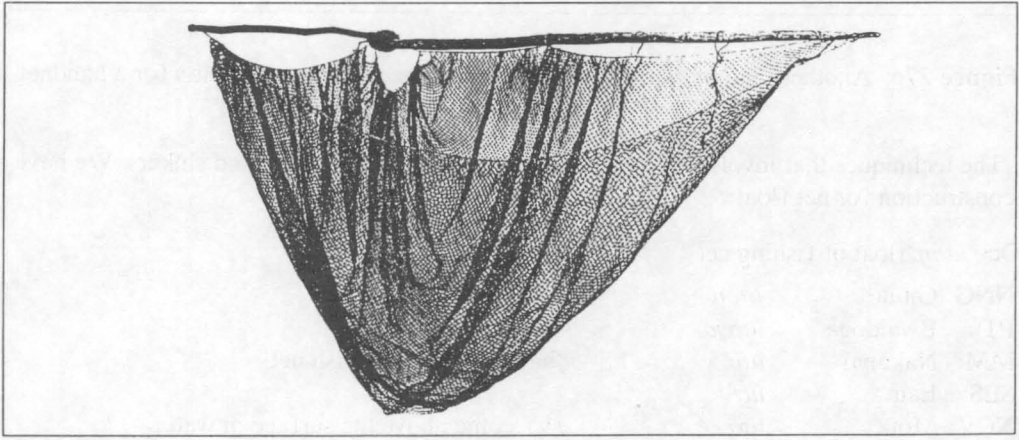

**Figure 27a:** POc *ku(p,pʷ)ena ‘fishing net’—generic term. (from Nevermann_1933:89)

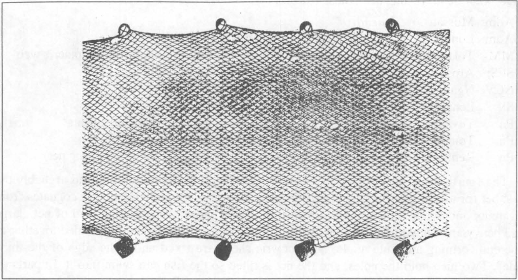

**Figure 27b:** Possibly POc *pukot ‘a seine net’, with wooden floats (POc *utoŋ) and stone sinkers (POc *patu) (from Nevermann_1933:89)

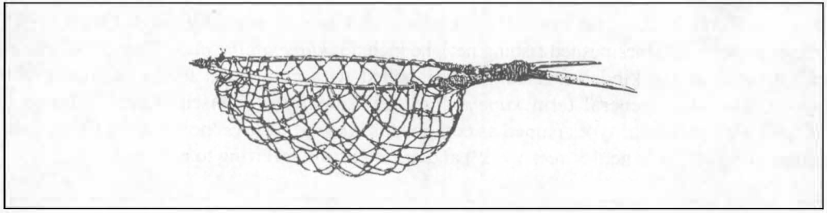

**Figure 27c:** Another kind of *ku(p,pʷ)ena. We lack a specific reconstruction for a handnet. (from Nevermann_1933:89)

The techniques that involve large nets usually require use of floats and sinkers. We have a reconstruction for net float:

| **POc** |  | *utoŋ | ‘float of fishing net’ |
| --- | --- | --- | --- |
| NNG | Gitua | *uton* |  |
| PT | Bwaidoga | *utoɣa* |  |
| MM | Nakanai | *uto* | ‘handle or stick of fish net’ |
| SES | Lau | *uo* |  |
| NCV | Mota | *uto* | [V] ‘come above the surface in water’ |
| Mic | Ponapean | *ūs* |  |
| Mic | Satawalese | *wūs, wuso-* | ‘any kind of wood that floats well’ |
| Fij | Bauan | *uto-uto* |  |
| Fij | Rotuman | *ut* |  |
| Pn | Tongan | *uto* |  |
| Pn | Rarotongan | *uto* |  |

There is also a competing form that co-exists with *utoŋ in the Central Pacific, PCP *vuta (Rotuman *hufa* ‘float on a fishing net’, Tikopia *futa* ‘net float’).

The only terms I can locate for sinker are reflexes of POc *patu ‘stone’, or the name of the cowrie shell which is sometimes used as a sinker:

| **PMP** |  | *buliq | ‘cowrie shell’ (ACD) |
| --- | --- | --- | --- |
| **POc** |  | *buli(q) | ‘cowrie shell; cowrie shell used as net sinker’ |
| SES | Sa’a | *puli* |  |
| Pn | Tuvalu | *pule* |  |

Other reconstructions that can be included within the vocabulary of nets are:

| **POc** |  | *sika | ‘netting needle’ |
| --- | --- | --- | --- |
| PT | Kilivila | *(va)sia* | ‘needle’ |
| Mic | Kiribatese | *rika* |  |
| Fij | Rotuman | *siʔa* |  |
| Fij | Bauan | *sika (ni lawa)* |  |
| Pn | Tongan | *hika* | ‘mesh needle, used in making nets’ |
| Pn | East Futunan | *sika* | ‘shuttle used for net-making’ |
| Pn | Hawaiian | *hiʔa* | ‘shuttle or needle for making nets’ |

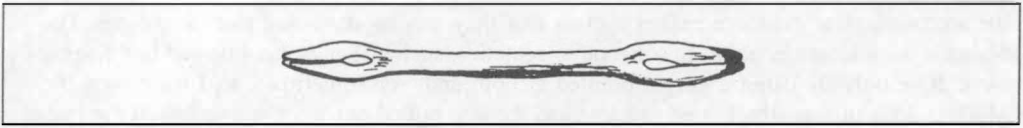

**Figure 28:** POc *sika ‘netting needle’

| **POc** |  | *mata- | ‘mesh of net’ |
| --- | --- | --- | --- |
| NNG | Kove | *mata* | ‘net gauge’ |
| PT | Molima | *mata-* | ‘net gauge’ |
| SES | Arosi | *mā* | ‘hole; opening; mesh of net’ |
| SES | Kwaio | *mā* | ‘k.o. fish weir; space through which birds frequently fly, where traps are set up’ |
| Pn | Māori | *mata* | ‘mesh of net’ |
| Pn | Hawaiian | *maka* | ‘mesh of net’ |

POc *mata- and its reflexes in many contemporary languages extend to a range of concepts that carry the idea of an opening, a doorway, something allowing access, and thus the mesh of a net. Evidence is that it is used in connection with nets in both Western Oceanic, as ‘net gauge’, and Eastern Oceanic, as ‘mesh of net’. Presumably the POc term embraced the idea of ‘mesh of net’ in both places, but in WOc languages reflexes now refer to the instrument used to maintain uniform mesh when net-making.

Another term for net gauge is found in Eastern Oceania:

| **PCP** |  | *qava | ‘net gauge’ |
| --- | --- | --- | --- |
| Fij | Bauan | *yava (ni lawa)* |  |
| Pn | Samoan | *afa* | ‘mesh stick’ |
| Pn | Rennellese | *ʔaha* |  |

## 3. Scareline

Some communities use a scareline for fishing, in which leaves are tied to a long rope which is drawn through the water. A term for this has been reconstructed to PCP level, although it is possible that cognates are derived from POc *raun ‘leaf’:

| **PCP** |  | *rau | ‘dragline, scareline, made from rope and coconut leaves’ |
| --- | --- | --- | --- |
| Fij | Wayan | *rau (sole)* | ‘barrier of leaves used in a *sole rau* or *ara-rau* fish drive’ |
| Pn | Tongan | *au* | ‘long fishing net made of rope and coconut leaves’ |
| Pn | Tikopia | *rau* | ‘sweep with a net’ |

However, in Andra (Admiralties) a leaf sweep is called *you*, pointing to POc *Rau(C) rather than *raun.

## 4. Angling implements

Use of fishhooks was evidently not an automatic ‘given’ in western Oceanic communities. Ann Chowning (pers.comm.) has commented that

> at the time of European contact, a number of societies did not use fish hooks, even though the archaeological evidence makes it clear that they can be attributed to POc culture. The Nakanai were a case in point. In some other societies, such as Sengseng, line and bait fishing were done only by using a gorge, pointed at both ends, or sometimes, as I have seen the Molima do, bait was simply tied to a line and the fish pulled out when it swallowed the bait. In many places fishing with hook and line is a post-contact phenomenon.

Nonetheless, the linguistic evidence leaves us in no doubt that POc speakers were familiar with the technique.

| **PMP** |  | *hapen | ‘fishing line’ (ACD) |
| --- | --- | --- | --- |
| **POc** |  | *apon | ‘fishing line’ (ACD) |
| Adm | Drehet | *cap* |  |
| MM | Petats | *ahon* | ‘string’ |
| SES | Gela | *(rau ni) avo(lo)* | ‘leaf kite for fishing’ |
| Mic | Kiribatese | *ao* | ‘fibre of coconut husk, fishline, twine’ |
| Mic | Kosraean | *æ* | ‘string, fishing line, rope, thread, cord’ |
| Fij | Bauan | *ðavo* | [v] ‘fish with rod (and line)’ |
| Pn | Tongan | *afo* | ‘cord, fishing line’ |
| Pn | Samoan | *afo* |  |

| **PMP** |  | *kawil | ‘hook’ (Blust 1972a) ; ‘fish hook’ (Dahl 1973) |
| --- | --- | --- | --- |
| **POc** |  | *kawil | [N] ‘hook; fishhook’ |
| Adm | Baluan | *kow* |  |
| NNG | Kairiru | *qawil* |  |
| MM | Tangga | *auil* |  |
| MM | Roviana | *gaili* | ‘fishhook made from pearlshell and turtle shell, used in trolling’ |
| SES | Arosi | *ʔawi* |  |
| NCV | Mota | *gau* | ‘fishhook’ |
| SV | Anejom̃ | *in-ɣowoc* |  |
| Fij | Wayan | *kau* | ‘fishhook of any kind’ |
| Pn | Tuvalu | *kau* | ‘fishhook, generic’ |

POc *kawil is widely attested. I have over fifty reflexes containing specific reference to fishhooks, occurring in all major subgroups. In Tuvalu it is used as a generic, followed by the name of the fish for which it is appropriate—*kau galata*, *kau palu*, etc. It has an obvious formal and semantic relationship with *kawi(t), *kawit-i- (V) ‘hook, catch hold of; fruit crook’ (Ch. 5, §10), but the origin of this relationship is not understood.

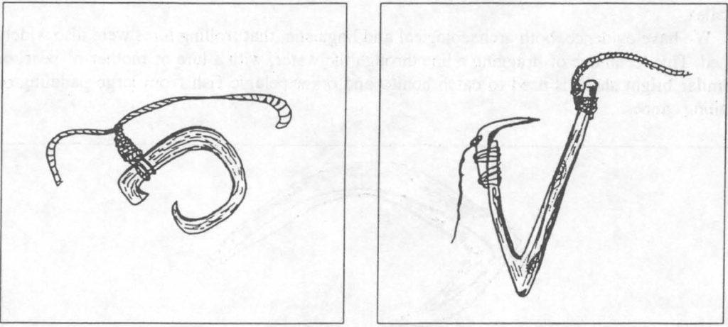

**Figure 29:** POc *kawil ‘fish hook’, POc *ta(g,k)o ‘(barbless?) fish hook’. On the left is a coconut shell fish hook; on the right is a wooden two-piece fish hook

| **POc** |  | *ta(g,k)o | ‘(barbless ?) fishhook’ |
| --- | --- | --- | --- |
| MM | Bola (Harua) | *toga* | ‘fishhook’ |
| MM | Maringe | *tʰaɣo* | ‘fishhook’ |
| SES | Bugotu | *taɣo* | ‘fishhook’ |
| SES | Lau | *aʔo* | ‘fishing rod’ |
| Pn | Rarotongan | *toko* | ‘an old type of wooden fishing hook (no barb)’ |

The extension of a meaning from a material to something made from that material is very common across languages (viz. English *glass*/*a glass*, *cork*/*a cork*). Examples occur in Oceanic languages as well (Bauan *gasau* ‘a reed; an arrow’, Tolai *vat* ‘a stone, a sinker’). POc speakers evidently made fishhooks from a variety of shells, and in some daughter languages the term for a particular shell has become the term for a fishhook (made from that shell?). For instance, POc *kima ‘clamshell’ is reflected in some Central Papuan languages as *kimai* ‘fishhook’ (Ross 1994a: 404). A similar example is:

| **PMP** |  | *qunap | ‘scales’ (Dempwolff 1938) |
| --- | --- | --- | --- |
| **POc** |  | *qunap | ‘turtle shell, fishhook’ |
| NNG | Rauto | *a-una* | ‘fishhook’ |
| MM | Tinputz | *unā* | ‘hook; fishhook’ |
| SES | Longgu | *ūnai* | ‘fishhook’ |
| SES | Ghari | *unua-na* | ‘turtle scales (not turtle shell)’ |
| SES | Arosi | *una-na* | ‘tortoiseshell’ (una ‘fish scales’) |
| Pn | Rennellese | *ʔuna* | ‘outer shell (of turtle +)’ |
| Pn | Samoan | *una* | ‘scale; scale of hawk’s bill turtle, i.e. tortoise-shell’ |
| Pn | Tuvalu | *una* | ‘turtle shell’ |
| Pn | Tikopia | *una* | ‘carapace of marine turtle’ |
| Pn | Hawaiian | *una* | ‘shell of turtle’ |

Final *-p is reconstructed because this item is almost certainly identical to POc *qunap ‘fish scales’. The Arosi (SES) verb derived from this term, *unahi-* ‘remove shell from turtle, scale a fish’ (see Ch. 6, §5.4), reflects *-p- and refers to the removal of both turtle shell and fish scales.

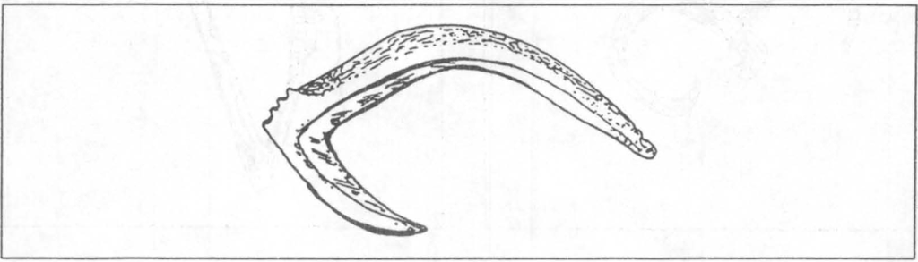

**Figure 30:** POc *bayan ‘trolling lure, trolling hook’

We have evidence, both archaeological and linguistic, that trolling lures were also widely used. This technique of dragging a line through the water, with a lure of mother-of-pearl or similar bright shell, is used to catch bonito and other pelagic fish from large paddling or sailing canoes.

| **POc** |  | *bayan | ‘fish bait, trolling lure, trolling hook’ |
| --- | --- | --- | --- |
| MM | Ramoaaina | *bain* | ‘bait’ |
| MM | Teop | *beana* | ‘bait’ |
| MM | Mono-Alu | *beana* | ‘bait’ |
| SES | ’Are’are | *pasa* | ‘a barbless bonito fishhook’ |
| SES | ’Are’are | *pā* | ‘fish bait’ |
| SES | Sa’a | *pasa* | ‘bonito lure of clamshell’ |
| SES | Sa’a | *pā* | ‘bait’ |
| SES | Arosi | *bā* | ‘bait for fish, food to entice into a trap’ |
| NCV | Mota | *pea* | ‘bait; to entice by a bait’ |
| SV | Lenakel | *nə-pien* | ‘bait’ |
| SV | Kwamera | *nə-piien* | ‘bait’ |
| SV | Anejom̃ | *ne-pyañ* | ‘bait’ |
| Fij | Wayan | *bā* | ‘trolling line with lure’ |
| Fij | Wayan | *baya* | ‘earthworm (earthworms are used for bait)’ |
| Fij | Bauan | *bā* | ‘Tongan variety of fishhook’ (*vakasavu bā* ‘troll’) |
| Fij | Bauan | *baða* | ‘worm (hence bait for fishing)’ |
| Pn | Tongan | *pā* | ‘fish hook, especially for catching bonito’ |
| Pn | Samoan | *pā* | ‘pearlshell lure; spinner including lure and hook’ |
| Pn | Tuvalu | *pā* | ‘bonito lure, generally made from mother-of-pearl shell’ |
| Pn | Tokelauan | *pā* | ‘generic term for trolling hook (*pa si malau*, *pa si aseu* etc.). All are made with pearlshell shanks and turtle-shell points’ |

It would appear that in some Southeast Solomonic languages and also in Fiji, reflexes of POc *bayan have split into doublets, evidently to distinguish ‘bait’ from ‘trolling lure’. Because there is crossover of meaning, with the long-vowel form referring to bait in one region and trolling lure in the other, it is assumed that the two splits occurred independently. Nor can the possibility of borrowing be discounted.

John Lynch (pers.comm.) points out that the final *-ñ* of Anejom *ne-pyañ* reflects earlier *-ni, implying POc **bayani. However, a number of the forms above reflect a loss of final *-n which would not have occurred if the form had been **bayani. It is possible, however, that Anejom *ne-pyañ* reflects a conflation of *bayan and *bani (below), forms which are similar but, it appears, not cognate.

| **PCEMP** |  | *paniŋ | ‘bait; fodder’ (ACD) |
| --- | --- | --- | --- |
| **POc** |  | *bani | ‘bait’ |
| NNG | Gitua | *bani* |  |
| PT | Tawala | *bani* |  |
| PT | Molima | *bani* | [v] ‘fish with hook and line’[^4] |
| MM | Ramoaaina | *ban* | ‘bait; use for bait’ |
| Mic | Ponapean | *pān* | ‘bait, lure’ |

A form PMP/POc *baŋi ‘bait’, is reconstructable on the basis of Javanese *baŋi* ‘bait’ and the obsolete Samoan *paŋi* ‘coconut bait for flying fish’. Its relationship to the reconstructions above is unclear.

## 5. Fish trap

| **PAn** |  | *bubu | ‘conical bamboo basket trap for fish’ (ACD) |
| --- | --- | --- | --- |
| **POc** |  | *pupu | ‘basketry fish trap’ |
| Adm | Lou | *pup* | ‘bamboo basket trap for fish’ |
| MM | Nakanai | *vuvu* | ‘k.o. fish trap’ |
| SES | Arosi | *huhu* | ‘large wickerwork eel trap’ |
| Mic | Kiribatese | *ū* | ‘trap for moray eel’ |
| Mic | Puluwatese | *wū* | ‘fish trap’ |
| Fij | Bauan | *vuvu* | ‘long narrow fish trap made of bamboo’ |

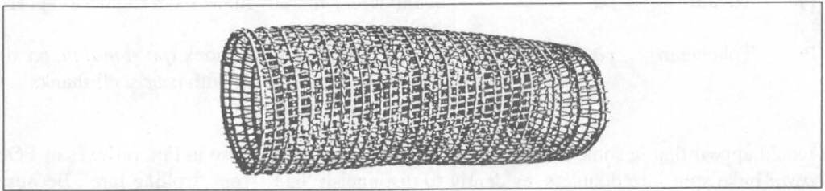

**Figure 31:** POc *pupu ‘basketry fish trap’ (from Nevermann_1934:226)

The term is widely attested. It is noteworthy that we have no Polynesian cognates. Instead we find PPn *fīnaki (Tongan *finaki*, Rarotongan *ʔinaki* ‘fish trap’; Hawaiian *hīnaʔi* ‘k.o. basket fish trap’).

## 6. Fish weir

| **POc** |  | *baRa | ‘fence, wall, enclosure’ |
| --- | --- | --- | --- |
| Adm | Mussau | *bala-bala* | ‘fence’ |
| Fij | Wayan | *bā (ni ika)* | ‘fish weir’ |
| Pn | Tongan | *pā* | ‘fence, wall, enclosure, especially for fish trap, made of stone or sticks’ |
| Pn | Rarotongan | *pā* | ‘fish weir of stone walls’ |

The POc term *baRa ‘fence, wall, enclosure’ (Ch. 3, §3.6) has evidently acquired an additional specialised meaning in the Central Pacific, where it refers to a fish trap made of stone or sometimes of sticks. (The Lou (Admiralties) term *pas* ‘stone fish corral’ has unexplained *-s*, and at this stage cannot be accepted as a cognate.) In Oceania, walls of stone or coral are constructed across channels in the reef to catch fish on a falling tide. In the Cook Islands (Rarotonga), *pā* has become a generic. Buck (1927:298) writes that:

> Most of the *pa* are very old, having been laid down far back in pre-European times. The channels were studied and the course taken by fish observed. The lines of the walls were laid down with such skill and accuracy that any departure from them ends in failure. The walls are made of loose coral rock. The most important weirs are named, and are owned by particular families. No outsider can use a weir without permission from the hereditary owners.

He describes various types of weirs, for example, *pa kiokio* (roughly Z-shaped), *pa tute* (temporary), and *pa tuakirua* (V-shaped with opening towards the sea).

## 7. Fish poison

| **PMP** |  | *tuba | ‘*Derris* fish poison’ (Dempwolff 1938) |
| --- | --- | --- | --- |
| **POc** |  | *tupa | ‘*Derris* fish poison’ |
| NNG | Aria | *tuva* |  |
| NNG | Kove | *tuva* |  |
| PT | Molima | *tuva* |  |
| PT | Kilivila | *tuva* | ‘poisonous root used for fishing’ |
| PT | Motu | *tuha* |  |
| MM | Vitu | *tuva* |  |
| MM | Tigak | *tua* |  |
| MM | Teop | *suva* |  |
| SES | Gela | *tuva* |  |
| SES | Sa’a | *uha, uhe* |  |
| NCV | Uripiv | *na-tuv* | ‘fish poison vine’ |
| Fij | Wayan | *tuva* |  |

| **POc** |  | *puna | ‘vine used for fish poison’ |
| --- | --- | --- | --- |
| Adm | Lou | *pun* | ‘vine used for fish poison’ |
| MM | Tolai | *vun* | ‘root with which fish are poisoned; to kill or benumb fish with poison of this name’ |
| MM | Roviana | *buna* | ‘littoral vine (macerated and thrown into rock pools, it stupefies fish)’ |
| SV | Lenakel | *no-un* | ‘fish poison’ |

From North New Guinea and New Ireland we have been able to reconstruct a lower-level term:

| **PWOc** |  | *(m,mʷ)ali | ‘*Derris* root’ |
| --- | --- | --- | --- |
| NNG | Gitua | *(waro)mali(ŋ)* |  |
| MM | Nalik | *mal-mal* |  |

The method of stunning fish by throwing pounded *Derris* root into pools is widespread, and the three terms seem to have identical reference, although *Derris elliptica* is not mentioned specifically in relation to *puna. Describing the technique used by Sa’a speakers, a Southeast Solomons language, Ivens (1927 (reissued 1972):389) writes that:

> … fish in streams are poisoned by a preparation. The bark of the edible *Barringtonia* tree, the one with red flowers, is stripped off and heated in the fire to bring out its bitter qualities. It is then beaten into shreds with stones in water and thrown into the place chosen. Along with it they use the grated nuts of the barringtonia speciosa [sic.], a littoral tree. A third ingredient is made from pounded sections of a creeper called *uhe*, the juices of which are very bitter.

The last ingredient is obviously a variant of *uha*, a reflex of POc *tupa.

The kernel of the fruit of *Barringtonia asiatica* (POc *putun) is used for poisoning water in Samoa, while the Fijians use the outer portion of the same fruit (Blackwood 1935:354-355), but I have not been able to reconstruct a term for this.

## 8. Torch fishing

| **PMP** |  | *damaR | ‘resin, torch, light’ (Dempwolff 1938) |
| --- | --- | --- | --- |
| **POc** |  | *(d)rama(R) | [N] ‘torch’; [V] ‘fish at night with torch’ |
| Adm | Lou | *(ka)ram* | ‘torch’ |
| Adm | Lou | *ram-ram* | ‘fish at night by torchlight’ |
| Fij | Bauan | *rama-rama* | ‘lamp of coconut shell filled with oil’ |
| Pn | Tongan | *ama* | [V] ‘fish at night by torch-light; torch made of coconut spathes bound together’ |
| Pn | Samoan | *lama* | ‘torch (made of dry coconut leaflets +); fishing with torches’ |
| Pn | Māori | *rama* | ‘torch; eeling with torches’ |

## 9. Pointed weapons

Most Oceanic languages contain a number of terms for spear, and it is probable that POc was no exception. There are various ways in which spears can be physically distinguished. There may be a distinction between fishing, fowling and fighting spears. Often, but not always, fishing spears have three or more prongs. Shorter spears can be used for thrusting, longer spears for hurling. Spears can be multi-barbed, have a single barb, or be barbless. They can be made with a head that separates from the shaft. Every language community will name its spears according to combinations of these and possibly other properties. Although we have been able to reconstruct perhaps six POc terms, it has been difficult to distinguish between them, other than to single out *tara and *kuj(u,i)r as probably fish spears. At the generic level-and that is itself a flexible category which can include arrows, and possibly other pointed weapons such as darts and spikes—*qio(r,R) seems to have the widest distribution, although it does not occur east of Vanuatu. For the Central Pacific, *sao(t) seems the most likely generic term. In POc times, some spears would have had obsidian heads, and the term used for these was evidently *koto ‘obsidian head of spear’ (Ch. 4, §4.1.3).

| **PMP** |  | *saet | [N, v] ‘spear’ (ACD) |
| --- | --- | --- | --- |
| **POc** |  | *sao(t) | [N] ‘spear’ |
| SV | Sye | *sau* |  |
| Fij | Wayan | *sā* | ‘spear; harpoon’ |
| Fij | Rotuman | *jao* |  |
| Pn | Tongan | *tao* | ‘spear; javelin’ |
| Pn | Rennellese | *tao* | ‘spear or dart for fishing, fighting, fowling’ |
| Pn | Hawaiian | *kao* | ‘dart; fish spear; javelin; spike as on the tail of a stingray’ |
| Pn | Rarotongan | *tao* | ‘short throwing spear’ |

| **POc** |  | *qio(r,R) | ‘spear, arrow’ (Ross 1994a: 464) |
| --- | --- | --- | --- |
| NNG | Lukep | *yu* | ‘arrow; spear traditionally used for pig hunting and fighting’ |
| NNG | Kaiwa | *ī* | ‘arrow’ |
| NNG | Manam | *io* | ‘long lance, whose wooden spear point has prongs on four sides’ |
| NNG | Uvol | *io* | ‘arrow’ |
| PT | Anuki | *io* | ‘spear’ |
| PT | Bwaidoga | *ɣio* | ‘spear’ |
| PT | Kalokalo | *gio* |  |
| PT | Tawala | *iyola* | ‘fish spear’ |
| PT | Balawaia | *gio* | ‘spear’ |
| PT | Motu | *io* | ‘spear’ |
| MM | Konomala | *iu* | ‘shoot; arrow’ |
| MM | Tangga | *iu* | ‘fish spear’ |
| SES | Lau | *īo* | ‘a war arrow; a poisoned spear’ |
| NCV | Nguna | *na-io* | ‘spear’ |

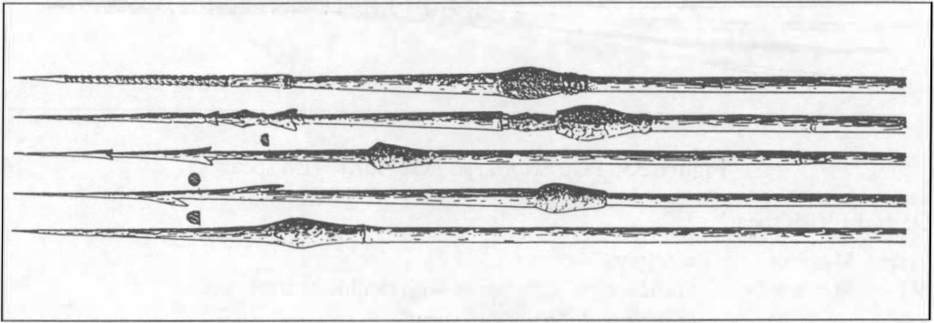

**Figure 32:** POc *qio(r,R), POc *sao(t), POc *bako all ‘spear’ or ‘k.o. spear’ (the above are Admiralties spears from Nevermann_1934:345)

As a subset of the above, certain NNG languages have inserted a medial consonant derived from epenthetic glides: Kove *iðo* ‘spear’; Bariai *ido* ‘arrow’; Gitua *izo* ‘spear’; Wogeo *iwo* ‘spear’. This appears to be a local feature, but not attributable to a common protolanguage.

| **PMP** |  | *baŋkaw | ‘barbless spear’ (ACD) |
| --- | --- | --- | --- |
| **POc** |  | *bako | ‘spear’ |
| MM | Hoava | *ba-bao* |  |
| SES | Malango | *bao* |  |
| SES | West Guadalcanal | *bao* |  |

(In all these languages, *k is regularly lost.)

| **POc** |  | *kuj(u,i)r | ‘fish spear’ (based on Ross 1994a) |
| --- | --- | --- | --- |
| PT | Kalokalo | *kudila* |  |
| PT | Iduna | *hudila* |  |
| PT | Motu | *udi* |  |
| MM | Nakanai | *kusi* | ‘multi-pronged fish spear’ |
| MM | Notsi | *kucil(a)* | ‘arrow’ |
| MM | Siar | *kusur* |  |
| MM | Meramera | *kusul(u)* |  |
| MM | Kandas | *(kabo)kusur* |  |
| MM | Laghu | *kuroho* | ‘spear’ |
| SV | Kwamera | *kahar-kahar* | ‘type of arrowhead made of three prongs, used for spearing fish’ |
| Pn | Tuvalu | *koho* | ‘thrusting spear’ (Nanumaga dialect; *u* > *o* unexpected) |

There is sufficient consistency among the glosses of this set to suggest that the POc form indeed referred to a multi-pronged fish spear.

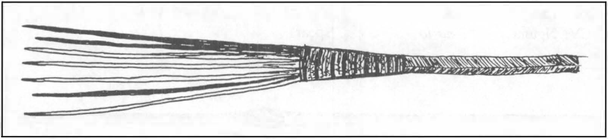

**Figure 33:** POc *kuj(u,i)r, POc *tara ‘fish spear’

| **POc** |  | *tara | ‘fish spear’ |
| --- | --- | --- | --- |
| Adm | Mussau | *tala(ŋai)* |  |
| PT | Molima | *tala(beya)* | ‘spear with double or triple point’ |
| PT | Molima | *tala(dabadaba)* | ‘k.o. spear’ |
| MM | Tolai | *ta-tara* |  |
| Pn | Niuean | *tala* | ‘sharp-pointed object; barb; prong’ |
| Pn | Rapanui | *tara* | ‘hom; thorn; spur’ |
| Pn | Mangareva | *tara* | ‘spine; hom; thorn’ |
| Pn | Anutan | *tara* | ‘fishhook barb’ |

It seems from Western Oceanic and Mussau glosses that the original POc meaning of *tara is probably ‘fish spear’. Pn glosses indicate a later narrowing of meaning to ‘barb’ or ‘prong’.

| **POc** |  | *sua | [N, V] ‘spear (weapon retained in the hand)’ |
| --- | --- | --- | --- |
| NNG | Manam | *sua(pu)* | [N] ‘fish spear’; [V] ‘spear’ |
| NNG | Poeng | *sue* | ‘bone, needle’ |
| SES | Gela | *sua* | ‘spear without barbs’ |
| SES | Longgu | *sua* | [N] ‘spear’ |
| SES | Longgu | *sua-* | [VT] ‘pull out (spear, stick +)’ |
| SES | Lau | *sua* | ‘spear’ |
| SES | Kwaio | *sua* | ‘spear’ |
| Fij | Bauan | *sua(k)* | ‘stab; pierce with a spear (retaining hold of the weapon); husk a coconut’ |
| Pn | Samoan | *sua* | ‘thrust’ |

Other terms used to describe the action of spearing are derived from POc *soka, *soka -i-* (V) ‘pierce; stab, poke hole in (s.t.)’ (Ch. 9, §4.1).

The following is a lower-level reconstruction for spear:

| **PEOc** |  | *saRi | ‘k.o. spear’ |
| --- | --- | --- | --- |
| NCV | Tamambo | *sari* | ‘spear’ |
| Fij | Wayan | *sai-sai* | ‘arrow or spear with three or more prongs, used for fish, bats +’ |

The bow, although evidently not as widespread as the spear, is used both for fighting and, in a smaller version, for shooting birds and other small game. It seems that *pusuR was the POc term for the bow and arrow, *(p,pʷ)anaq more probably for the act of shooting.

| **PAn** |  | *busuR | ‘hunting bow’ (ACD; Dempwolff 1938) |
| --- | --- | --- | --- |
| **POc** |  | *pusuR | ‘bow and arrow’ |
| NNG | Kis | *us* | ‘arrow’ |
| PT | Kuni | *budu* | ‘arrow’ |
| MM | Petats | *husul* | ‘bow’ |
| NCV | Southeast Ambrym | *his* |  |
| Fij | Wayan | *vuðu* | ‘bow’ |

| **PMP** |  | *panaq | ‘shoot’ (Dempwolff 1938) |
| --- | --- | --- | --- |
| **POc** |  | *(p,pʷ)anaq | ‘bow’ |
| **POc** |  | *(p,pʷ)anaq, *(p,pʷ)anaq-i- | ‘shoot’[^5] |
| NNG | Tuam | *paneg* | ‘bow’ |
| NNG | Mapos Buang | *vaneh* | ‘shoot’ |
| NNG | Medebur | *pan* | ‘bow’ |
| MM | Tolai | *panak* | ‘bow for shooting’ |
| SES | Gela | *vanahi-* | ‘shoot at’ |
| SES | Kwaio | *fana* | ‘hunt’ |
| NCV | Mota | *vene* | ‘shoot with a pointed arrow’ |
| NCV | Tamambo | *(i)vine* | ‘arrow’ |
| NCV | Fortsenal | *vinai-* | ‘shoot (with arrow)’ |
| Mic | Kiribatese | *pana* | ‘shoot at fish with band of rubber and long arrow’ |
| Fij | Bauan | *vana* | ‘shoot with arrow or gun’ |
| Pn | Tongan | *(kau)fana* | ‘bow’ |

With regard to the reconstruction of *(p,pʷ), see Chapter 2, §2.1.

| **POc** |  | *tibʷa(ŋ) | ‘dart, arrow (not a fighting weapon)’ (Ross 1994a: 464) |
| --- | --- | --- | --- |
| **POc** |  | *tibʷaŋ-i- | ‘shoot with dart, arrow’ |
| PT | Dobu | *tupu* | ‘bow, arrow’ |
| PT | Tawala | *diba* | ‘small pretend spear’ |
| PT | Taboro | *diba* | ‘spear, fish spear’ |
| PT | Motu | *diba* | ‘arrow’ |
| MM | Notsi | *tipi* | ‘shoot’ |
| MM | Roviana | *tupi* | ‘arrow or dart’ (vowel metathesis) |
| NCV | Mota | *tigʷa* | ‘blunt arrow for birds; shoot (not in fighting)’ |
| NCV | Mota | *tigʷaŋ* | ‘shoot and hit’ |
| NCV | Tamambo | *tibua* | ‘shoot an arrow’ |
| NCV | Raga | *tibʷa* | ‘shoot’ |
| NCV | Atchin | *cip* | ‘blunt arrow’ |
| NCV | Paamese | *a-tuvo* | ‘arrow’ |
| NCV | Paamese | *tuvo* | ‘shoot’ |
| NCV | Nguna | *na-tipʷa* | ‘arrow, (fish) spine, (pine) needle’ |
| NCV | Nguna | *tipe-* | ‘shoot with bow’ |
| Fij | Bauan | *tiga* | ‘reed dart, used in game of veitiqa’ |
| Fij | Wayan | *tigʷe* | ‘throw reed or dart horizontally controlled by end of forefinger, with aim of making dart skip up when it hits ground’ |
| Pn | Tikopia | *tika* | ‘k.o. arrow thrown in game’ |
| Pn | Māori | *teka* | ‘dart used in a traditional game’ |
| Pn | Hawaiian | *keʔa* | ‘dart, bow; shoot with bow and arrow’ |

The glosses of the reflexes of POc *tibʷa(ŋ) suggest strongly that it referred prototypically to small, arrow-like objects or darts that did not have a killing function. The initial-consonant voicing of the PT forms (other than Dobu *tupu*, which may not be cognate) is unexplained.

| **PAn** |  | *deles | ‘bowstring’ (ACD) |
| --- | --- | --- | --- |
| **POc** |  | *lolo(s) | ‘bowstring’ |
| SES | ’Are’are | *i-roro* |  |
| SES | Sa’a | *i-lolo* |  |
| Fij | Wayan | *lolo* | ‘bend, flex; bent, flexed’ |
| Fij | Bauan | *(ka)lolo* | ‘bent to one side by excessive burden on shoulder’ |
| Pn | Tikopia | *(ka)roro* |  |
| Pn | Tahitian | *(a)roro* | ‘stay to mast of canoe’ |

The Fijian and the Tahitian cognates have strayed semantically, yet still retain the idea of something held so tautly that it distorts.

## 10. Club

Across the Pacific, the kind of weapon that is labelled ‘club’ varies from the great knobbed, obsidian-studded roots that can be seen in the Bishop Museum in Honolulu, to the flat round stone clubs of the Motu (*gahi*), to the smaller, lighter throwing clubs of Fiji (*i ula*: Clunie 1977), and to the Kiribatese *kati-popuki*—about four feet long, pointed at both ends, used for warding off a spear, making a thrust, or wielding as a club (Hudson 1841, quoted in Koch 1986:249), which might equally be classified as a shield or lance. I consider these to be more or less marginal examples of what is basically a blunt, heavy instrument, wielded in the hand for bludgeoning.

In the Southeast Solomons, Fiji and Polynesia at least (I have little information from Western Oceania), clubs have an importance beyond that of simply weapons. They often carry ceremonial weight. Many are heirlooms with names and magical powers. Special reverence is accorded the war club. To the extent that it is possible to distinguish war clubs from hunting clubs, I do not intend to delve further into the culture and terminology of the former. It is my guess that hunting clubs would have carried less cultural significance, and as a result, been labelled more broadly. Two terms have been reconstructed.[^6] In each case I have included all known cognates. It will be apparent that neither reconstruction is particularly soundly based. Nor do their cognates provide much information as to the shape, material or specific function of each club:

| **POc** |  | *paru | [N, v] ‘club’ |
| --- | --- | --- | --- |
| PT | Molima | *pulu(mai)* | ‘war club, wooden and flat-sided, used to kill by hitting throat or back of neck’ |
| MM | Teop | *varu* |  |
| NCV | Paamese | *vau(lev)* |  |
| SV | Lenakel | *nɛ-pɛrāu* | ‘club wielded by the leader of various dances in a nɛkoviār (dance cycle)’ |
| Fij | Bauan | *ravu(ta)* | ‘club s.o. or s.t.’ (metathesis) |

and an even more questionable reconstruction, in view of irregular final vowels:

| **POc** |  | *gapi | ‘(stone?) club’ |
| --- | --- | --- | --- |
| PT | Motu | *gahi* | ‘flat stone club’ |
| SES | Fagani | *ɣafe* | ‘club’ |
| SES | Lau | *afui* | ‘k.o. club’ |

## 11. Slingshot

| **POc** |  | *maga | ‘stone; slingshot’ |
| --- | --- | --- | --- |
| MM | Vitu | *(ta)maga* | ‘slingshot’ (*maga-maga* ‘sand’) |
| MM | Bulu | *(ta)maga* | ‘slingshot’ |
| MM | Nakanai | *(tu)maga* | ‘sling made of bark-cloth, used for hunting birds and bats’ |
| SES | Talise | *maka(ra)* | ‘stone’ |
| Pn | Tongan | *maka(tā)* | ‘sling’ (*maka* ‘stone, rock’, *tā* ‘hit’) |
| Pn | Tikopia | *maka* | ‘stone for sling; sling for hurling stones’ |
| Pn | Rarotongan | *maka* | [v] ‘throw; hurl; sling’; [N] ‘sling, stone’ |
| Pn | Tahitian | *maʔa* | [N, V] ‘sling’ |

| **POc** |  | *kaio | ‘sling; to turn round and round’ |
| --- | --- | --- | --- |
| MM | Bilur | *aio* | ‘slingshot’ |
| SES | Arosi | *ʔaro(rabu)* | [N] ‘sling’ (*ʔaro* ‘turn round and round’, *rabu* (V) ‘strike or knock s.t.’) |

Slingshots would have been used for hunting birds, flying foxes and perhaps the cuscus.[^7] Although it is assumed that ordinary well-shaped stones were used, Green (1979: 39) has documented a pointed-end *Tridacna* shell slingstone from Main Reef Islands circa 1000 BC.

## 12. Trail and pitfall spikes

| **PMP** |  | *suja | ‘bamboo trail or pitfall spike’ (Blust 1976b) |
| --- | --- | --- | --- |
| **POc** |  | *suja | ‘sharpened stake set in ground to stop or wound animals or enemies’ |
| MM | Sursurunga | *sus* | ‘sharp-pointed stick, used in traps or for breaking coconuts open; make holes in’ |
| SES | Arosi | *suda* | ‘stake set slanting and sharpened in a pit for the enemy’ |

The setting of sharp spikes or slivers of wood or bamboo, hardened in the fire, either directly into a path, or at the bottom of a pit, is also known in Fiji (Bauan *soki*, ‘spike’; *lovosa* ‘pitfall man trap’), but I cannot locate any other Oceanic reflexes of PMP *suja. Nonetheless, given the external evidence, the reconstruction must stand. It may be that this was primarily a warfare technique, and that a different term was used for the pit-trapping without spikes of pigs and smaller ground animals like lizards.

## 13. Snare trap

Birds are caught for food throughout the region, often by netting or by ground snares, fashioned from a spring-laden twig and a noose. Although I can locate many terms which refer to snare, noose and bird trap, the cognate sets collected are few. The following term was both a noun and a verb. Terms reflecting **piti in MM and SES languages seem to be local inventions formed from a noun **pit (after loss of POc *-a) with the addition of the transitive suffix *-i-.

| **POc** |  | *pʷita, *pʷita-i- | [N] ‘snare’; [V] ‘tie by encircling, ensnare’ |
| --- | --- | --- | --- |
| NNG | Lukep | *wit* | ‘tie by encircling’ |
| NNG | Lukep | *wit(kala)* | ‘tie together’ |
| NNG | Lukep | *pit* | ‘snare, trap; to trap’ |
| NNG | Mangap | *mbit* | ‘tie up with rope, fasten’ |
| NNG | Mangap | *(na)pit-pit* | ‘snare, trap for rats, pigs, bandicoot’ (*na-* indicates a borrowing from Kilenge) |
| NNG | Poeng | *(sam)pite* | ‘tie securely, tighten’ |
| NNG | Poeng | *(bago)pita* | ‘fasten (to help it to float)’ |
| NNG | Takia | *pite(lak)* | ‘tie on (as grass-skirt)’ |
| MM | Sursurunga | *puti* | ‘tie together’ |
| MM | Ramoaaina | *pita* | ‘hang up in the house; tie to the end of anything’ |
| MM | Ramoaaina | *pit* | ‘tie’ |
| MM | Ramoaaina | *pit-pit* | ‘line, snare’ |
| MM | Ramoaaina | *piti* | [v] ‘snare’ |
| SES | Gela | *piti-* | ‘tie’ |
| SES | West Guadalcanal | *piti* | ‘tie’ |
| SES | Longgu | *piti-* | ‘trap an animal’s leg; tie s.t. around ankle or wrist’ |
| Pn | Tokelauan | *fi-fita* | ‘(garments) be too tight’ |
| Pn | Māori | *ɸita* | ‘firm, secure, fast’ |

With regard to the reconstruction of *(p,pʷ), see Chapter 2, §2.1.

| **PEOc** |  | *taRi | ‘noose, snare’ |
| --- | --- | --- | --- |
| NCV | Mota | *tar* | [V] ‘lay (net +)’ |
| Fij | Bauan | *dai* | ‘snare or trap for catching animals’ |
| Fij | Wayan | *tai* | ‘snare or trap for catching animals’ |

## 14. Birdlime

Another widespread method of catching birds involves the use of birdlime. Hooley describes the technique used by Mapos Buang speakers in the Huon Gulf region of New Guinea:

> The sap of this tree (*dagΣem*) is used as birdlime for catching birds. The sap is collected in a length of bamboo and is then heated over a fire. When it is boiling a stick is dipped in and twisted and the sap adhering to it is chewed to make it soft and then wrapped in cordyline leaves. The sap is then spread on a suitable tree branch so that when birds come to eat the fruit of that tree they are caught. (from word list held on computer file at ANU)

Blust (1983–84a) has reconstructed Proto WMP *pikat or *piket ‘birdlime’ and *mamikat or *makiket ‘snare birds with birdlime’, but I have not been able to locate any Oceanic reflexes. The reconstruction given below evidently refers generally to gum or resin, although in one instance, in Arosi, it is the first element in a compound, *buruhasi*, meaning ‘bird trap’. The second element, *hasi*, means ‘adhere’.

| **PMP** |  | *bulit, *pulit | ‘caulk, fill up a hole or crack with viscous material’ (ACD) |
| --- | --- | --- | --- |
| **POc** |  | *bulit | ‘gum; resin’ |
| MM | Tolai | *bulit* | ‘gum of any tree, especially that used for putty or gum’ |
| MM | Nakanai | *bulubulu(aga)* | ‘plant with sticky fruit used for catching birds’ |
| SES | Arosi | *buru(hasi)* | ‘bird trap; gum of banyan or other tree put at intervals along a pole’ |
| SV | Lenakel | *(noua-neha)pʷit* | ‘sap, glue’ |
| Fij | Bauan | *bulu-bulut(i)* | ‘(soil) sticky, doggy’ |
| Fij | Rotuman | *pulu* | ‘gum; sap’ |
| Pn | East Uvean | *pulu* | ‘resin’ |

## 15. Archaeological evidence

Evidence comes both directly from the existence of artefacts themselves in archaeological sites—the fishhooks, trolling lures, stone fish traps, spear tips and so on—and indirectly through analysis of remains in Lapita middens, which provide evidence of Lapita people’s diet and (indirectly) for food procurement techniques.

Spriggs (1997a: 114) summarises non-vegetable food traces from an Eloaue site on Mussau, east of the Admiralties, believed to have been occupied between about 3,500 and 2,500 years ago. (Eloaue is a low, flat, coral island south-east of the high island of Mussau.)

> Large quantities of shell midden occurred in the site … The three Oceanic domesticates, pig, dog and chicken, were present but only in small numbers. 95 per cent of the bone was of fish, mainly inshore species, and turtle. Present too in small quantities were porpoise, reptiles, birds, rats and also the phalanger *Spilocuscus maculatus* (p. 117).

A similar range of fauna to Mussau’s occurs in the Lapita sites in the Arawe Islands, off the south-west of New Britain, with the addition of a wallaby, *Thylogale browni* and the flightless cassowary as introduced species (p. 120). A site on Watom, off the north-east tip of New Britain, adds bandicoot to the faunal repertoire (p. 124). Lapita sites from the Solomons provide little evidence, while the Reef-Santa Cruz Islands, next in line as one moves east, show a decline in the range and diversity of animal life available for food, a decline that increases as one moves progressively further out into the Pacific. Spriggs records that “hunting took place of what local species of birds, bats and sea creatures such as turtles and dugongs there were, as well as collecting of reef and lagoon fish and shellfish”. (p. 135)

Artefacts are considered alongside the linguistic evidence. With regard to angling, we have the following POc reconstructions:

| *apon | ‘fishing line’ |
| --- | --- |
| *kawil | ‘fishhook’ |
| *ta(g,k)o | ‘barbless (?) fishhook’ |
| *qunap | ‘turtle shell; fishhook’ |
| *bayan | ‘trolling lure’ |
| *bani, *baŋi | ‘bait; fodder’ |

Of these items, fishhooks have proved the most useful in developing local culture sequences. One-piece fishhooks made from several kinds of shell are now well documented from a number of Lapita sites, ranging from Talepakemalai (Mussau) to Lolokoka (Niuatoputapu, Tonga), one site at the latter dating back to about 2800 BP. “Most of the Mussau hooks are fairly large (about 5 cm in shank length) and were probably designed for hand-lining from canoes, in order to catch larger benthic species such as groupers. A few hooks are smaller, however, and could have been used for taking smaller species on reefs and along coastlines.” (Kirch 1997: 200). Most hooks so far found are of *Turbo*, *Trochus* and pearlshell. Linguistic evidence supports clamshell and tortoiseshell. Presumably all of these were used, as well as the less durable coconut shell, bone and *Pemphis acidula* wood, which are in use today. Also from Mussau sites come examples of carefully crafted lures made from *Trochus* shell. These trolling lures “are streamlined for hydrodynamic lift in the water, and have finely carved grooves for attaching both the line and hackles (probably feathers or pig bristles) near the recurved point”. (pp.200-201)

More elaborate two-piece fishhooks with separate shank and point were apparently a later development, appearing in Eastern Polynesia and possibly originating in the Marquesas Islands (Bellwood 1987:58).

A pertinent observation on the connection between present-day fishing techniques and those of the early Lapita settlers is made by Kirch and Yen (1982) in their study of the prehistory of Tikopia (initial settlement dates to around 2875-2750 BP). They have assembled a collection of one-piece fishhooks and three distinctive early trolling hooks made from trochus shell, which are associated with Lapita sites. They note (p.243) that:

> While we must be cautious in interpreting archaeological fishhooks on the basis of ethnographic observations of the use of modern metal hooks, the data are suggestive that Tikopia utilised a similarly broad range of angling strategies in prehistoric times. Group I hooks would have been best suited to catching small fry on the fringing reefs. Group II hooks, the most varied, were likely used for more than one strategy, and towline and bottom-fishing techniques, among others, seem likely. The largest specimens, Group III, would seem to have been intended for towline capture of carniverous pelagic fish or bottom fishing for large groupers, Ruvettus, and the like. Such an interpretation of the angling gear is consistent with the range of fish taxa identified in the Tikopia faunal material.

We have eight POc terms that relate to netting:

| *pukot | ‘fishing net, seine’ |
| --- | --- |
| *reke | ‘fishing net, seine net’ |
| *lawa((n,q)) | ‘k.o. fishnet’ |
| *ku(p,pʷ)ena | ‘net, generic term (?)’ |
| *utoŋ | ‘net float’ |
| *buli(q) | ‘cowrie shell used as net sinker’ |
| *sika | ‘netting needle’ |
| *mata- | ‘mesh of net’ |

Although netting itself will not endure, we have limited physical evidence of dragnetting from Tikopia in the form of cowrie shell net weights. Kirch and Yen (p.245) have been able to identify shells and stones from a Lapita site as net weights and line sinkers:

> Tikopia women frequently scour the reef flats with small two-handled dip nets, *te kuti*, the edge of which is weighted with small Cypraea shells. Such shells have the dorsum removed to facilitate lashing … Two line sinkers were [also] found, each consisting of a natural cobble … with an artificially pecked groove running laterally round the stone. Such grooved cobbles are still used on occasion by Tikopia fishermen.

It is unlikely that the remainder of our fishing terminology, with the possible exception of the stone fish weirs, can ever be supported by archaeological evidence:

| *pupu | ‘basketry fish trap’ |
| --- | --- |
| *baRa | ‘fence’ (‘fish weir’ only in PCP) |
| *tupa | ‘derris fish poison’ |
| *puna | ‘vine used for fish poison’ |
| *(d)rama(R) | (N) ‘torch’; (V) ‘fish at night with torch’ |

The pointed weapon terminology consists of:

| *sao(t) | (N, V) ‘spear’ |
| --- | --- |
| *sua | (N, V) ‘spear, weapon retained in the hand’ |
| *soka, *soka-i- | ‘pierce; stab’ |
| *qio(r,R) | ‘spear’ |
| *bako | ‘spear’ |
| *kuj(u,i)r | ‘fish spear’ |
| *tara | ‘fish spear’ |
| *koto | ‘obsidian head of spear’ |
| *pusuR | ‘bow and arrow’ |
| *(p,pʷ)anaq, *(p,pʷ)anaq-i-* | ‘bow’; (V) ‘shoot’ |
| *tibʷa(ŋ), *tibʷaŋ-i- | ‘dart, arrow; shoot with dart, arrow’ |
| *lolo(s) | ‘bowstring’ |

The only archaeological evidence we have for spears, bows and arrows, darts, etc. would seem to be obsidian and bone spear points. Triangular-sectioned obsidian blades are an artefact form produced only in the Manus Group and were almost certainly spearpoints (Spriggs 1997a:163). They were manufactured in the vicinity of the main obsidian sources in the Lou Island area by 2100 BP (pp. 162-164). Green (1979:39) documents a bone spear-point from Main Reef Islands circa 3100 BP.

I can find no archaeological evidence for any kind of club, our two (weakly supported) terms notwithstanding:

| *paru | (N, V) ‘club’ |
| --- | --- |
| *gapi | ‘stone? club’ |

However, for the slingshot we have pointed-end tridachna shell slingstones from Main Reef Islands documented by Green (1979:39):

[output not shown]

The trail and pitfall spikes, the snare trap and the birdlime lack any supporting evidence from archaeology.

| *suja | ‘sharpened stake set in ground’ |
| --- | --- |
| *pʷita, *pʷita-i- | (N, V) ‘snare’ |
| *bulit | ‘gum, resin (birdlime?)’ |

Although we can look to archaeology to confirm the hypothesis that durable artefacts will be found in sites associated with Oceanic-speaking communities, there is little hope of archaeological recovery of the perishable artefacts in question. Here, linguistics adds an extra dimension to research on the prehistory of Oceania.

## Notes

[^1]: *ŋ* for expected *n*.
[^2]: *ŋ* for expected *n*.
[^3]: *ŋ* for expected *n*.
[^4]: Chowning (pers.comm.) points out that the Molima, and also the inhabitants of Goodenough Island, traditionally made their fish hooks out of the leg of a phasmid insect. This presumably combined the functions of hook and bait.
[^5]: Tuam, Medebur, Tolai, Kiribatese *p-*, which normally reflects POc *b or *bʷ*, is unexplained.
[^6]: A putative third construction, POC *nalanala, ‘club’ (from Motu *tanala* ‘egg-shaped stone club’, Tolai *nalnal* ‘battle axe’, Maringe *nalanala* ‘wooden club’, Longgu *nalanala* ‘club’) is discounted on the basis of evidence that it is a borrowing from the Pidgin spoken along the east coast of Australia last century, this in turn deriving from *ŋalaŋala* ‘a hardwood club used in fighting and hunting’, a term from the language spoken around Sydney at the time of the first settlement (Jaki Troy, pers.comm.). The term *nalnal* still exists in Bislama (Ross Clark, pers.comm.).
[^7]: Chowning (pers.comm.) comments that slings were also used for warfare in some places, as among the Tolai and in the D’Entrecasteaux, including the Dobu area. The Molima say they were particularly popular for fighting from canoes.